# Untitled

Prof. Steven Dutt Ross

17/06/2021

This page lists some HTML widgets that are compatible with Crosstalk.

(To add a widget, please submit a PR with modifications to [this page](https://github.com/rstudio/crosstalk/edit/master/docs/widgets.Rmd).)

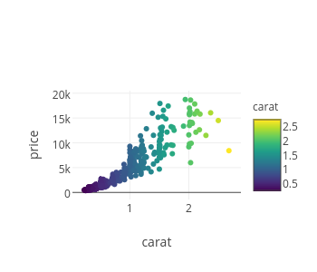

### [Plotly](https://cpsievert.github.io/plotly_book/)

**Author:** [Carson Sievert](https://github.com/cpsievert)

Plotly is a general purpose plotting library that outputs interactive web graphics using [plotly.js](https://plot.ly/javascript/).

[figure not shown]

```r
devtools::install_github("ropensci/plotly")
```

### [Leaflet](https://rstudio.github.io/leaflet/)

**Author:** [RStudio](https://github.com/rstudio)

Leaflet lets you easily generate interactive maps using R. It is a wrapper for the very popular [Leaflet JavaScript library](http://leafletjs.com/) by [Vladamir Agafonkin](http://agafonkin.com/en/).

```r
devtools::install_github("rstudio/leaflet")
```

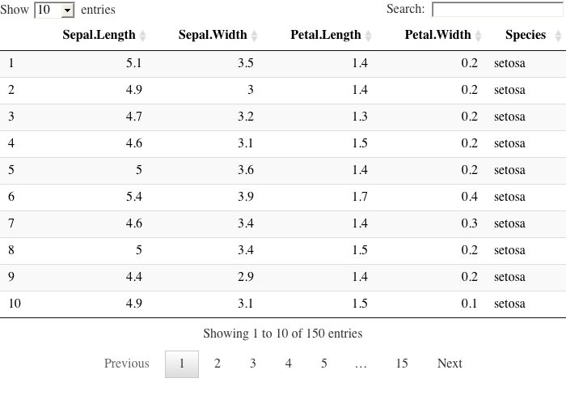

### [DT](https://rstudio.github.io/DT/)

**Author:** [RStudio](https://github.com/rstudio)

DT is a highly customizable data table library. It wraps the [DataTables plug-in for jQuery](https://datatables.net/).

```r
devtools::install_github("rstudio/DT")
```

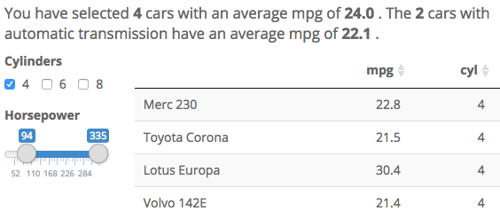

### [SummaryWidget](https://kent37.github.io/summarywidget/)

**Author:** [Kent Johnson](https://github.com/kent37)

A SummaryWidget displays a single summary statistic that updates when the Crosstalk selection changes. A SummaryWidget displays the count, sum or mean of one column of selected data.

```r
devtools::install_github("kent37/summarywidget")
```

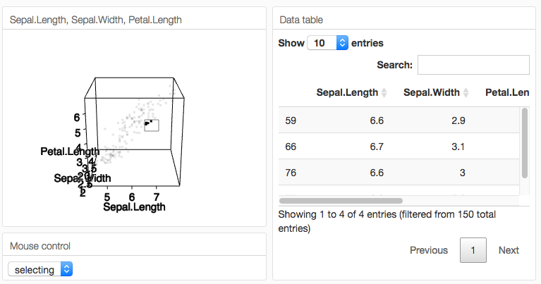

### [rgl](https://r-forge.r-project.org/projects/rgl/)

**Author:** Duncan Murdoch and Daniel Adler

rgl is a 3D visualization system based on OpenGL. It provides a medium to high level interface for use in R, currently modelled on classic R graphics, with extensions to allow for interaction. See the `?rgl::rglShared` help topic for details of `crosstalk` usage.

```r
devtools::install_github("r-forge/rgl")
```